# Tugas Kuliah MPDW P2

Afiq Dzakwan Anasti - G1401231058

2025-09-03

# 1 Import Libraries & Data

```r
library(GGally)
library(psych)
library(car)
library(carData)
library(olsrr)
library(dplyr)
library(TTR)
library(forecast)
library(lmtest)
library(orcutt)
```

```r
ipm_riau <- data.frame(
  Tahun = 2010:2023,
  IPM = c(68.65, 68.90, 69.15, 69.91, 70.33,
          70.84, 71.20, 71.79, 72.44, 73.00,
          72.71, 72.94, 73.52, 74.04)
)

ipm_riau
```

```
##    Tahun   IPM
## 1   2010 68.65
## 2   2011 68.90
## 3   2012 69.15
## 4   2013 69.91
## 5   2014 70.33
## 6   2015 70.84
## 7   2016 71.20
## 8   2017 71.79
## 9   2018 72.44
## 10  2019 73.00
## 11  2020 72.71
## 12  2021 72.94
## 13  2022 73.52
## 14  2023 74.04
```

# 2 Cek Korelasi

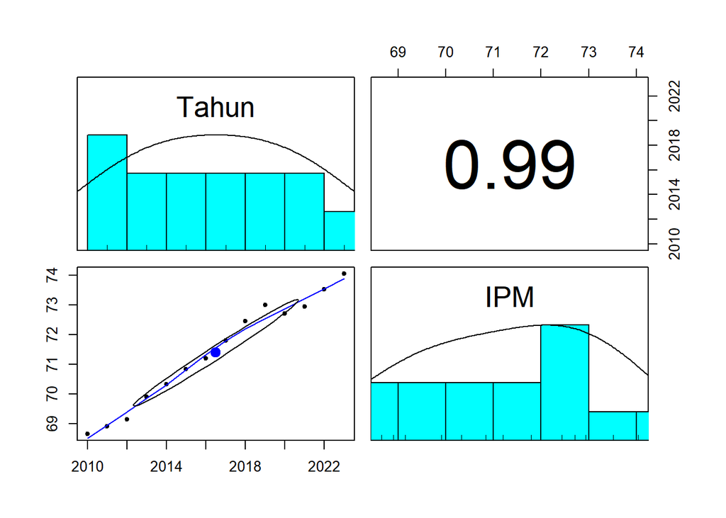

```r
pairs.panels(ipm_riau)
```

Berdasarkan scatter plot di atas, terlihat adanya hubungan / korelasi positif antara peubah tahun dengan nilai IPM, terlihat titik-titik pada plot yang naik ke arah kanan atas dengan nilai korelasi sebesar $0.99$.

# 3 Base Model

```r
model <- lm(formula = IPM ~ Tahun, data = ipm_riau)
summary(model)
```

```
##
## Call:
## lm(formula = IPM ~ Tahun, data = ipm_riau)
##
## Residuals:
##      Min       1Q   Median       3Q      Max
## -0.35930 -0.16080  0.00763  0.07401  0.55055
##
## Coefficients:
##               Estimate Std. Error t value Pr(>|t|)
## (Intercept) -785.47024   35.77736  -21.95 4.68e-11 ***
## Tahun          0.42492    0.01774   23.95 1.69e-11 ***
## ---
## Signif. codes:  0 '***' 0.001 '**' 0.01 '*' 0.05 '.' 0.1 ' ' 1
##
## Residual standard error: 0.2676 on 12 degrees of freedom
## Multiple R-squared:  0.9795, Adjusted R-squared:  0.9778
## F-statistic: 573.6 on 1 and 12 DF,  p-value: 1.685e-11
```

Model yang dihasilkan adalah
$$y_i=-785.470+0.425x_t$$
Berdasarkan ringkasan model dapat diketahui bahwa hasil uji F memiliki *p-value* < $\alpha$ (5%). Artinya, minimal terdapat satu variabel yang berpengaruh nyata terhadap model. Hasil uji-t parsial kedua parameter regresi, yaitu intersep dan koefisien regresi juga menunjukkan hal yang sama, yaitu memiliki *p-value* < $\alpha$ (5%) sehingga nyata dalam taraf 5%. Selanjutnya dapat dilihat juga nilai $R^2=0.980$. Artinya, sebesar 98% keragaman nilai IPM dapat dijelaskan oleh peubah tahun. Hasil ini menunjukkan hasil yang bagus, seolah mendapatkan hasil terbaik. Namun, kita perlu melakukan uji terhadap sisaannya seperti berikut ini

## 3.1 Cek Asumsi Klasik

### 3.1.1 Autokorelasi: Durbin-Watson

```r
(uji_autokol <- durbinWatsonTest(model,
                                 alternative="two.sided"))
```

```
##  lag Autocorrelation D-W Statistic p-value
##    1       0.4904218      1.004576    0.02
##  Alternative hypothesis: rho != 0
```

```r
ifelse(uji_autokol$p < 0.05, "Ada Autokorelasi", "Tidak Ada Autokorelasi")
```

```
## [1] "Ada Autokorelasi"
```

### 3.1.2 Homogenitas: Breusch-Pagan

```r
library(lmtest)
library(zoo)
(homogen_model <- bptest(model))
```

```
##
##  studentized Breusch-Pagan test
##
## data:  model
## BP = 1.1931, df = 1, p-value = 0.2747
```

```r
ifelse(homogen_model$p.value < 0.05, "Ragam Tidak Homogen", "Ragam Homogen")
```

```
##              BP
## "Ragam Homogen"
```

Berdasarkan uji formal Breusch-Pagan didapatkan nilai *p-value* > $\alpha$ (5%). Artinya, cukup bukti untuk menyatakan ragam homogen.

### 3.1.3 Normalitas: Kolmogorov-Smirnov

```r
library(nortest)
sisaan_model <- resid(model)
(norm_model <- lillie.test(sisaan_model))
```

```
##
##  Lilliefors (Kolmogorov-Smirnov) normality test
##
## data:  sisaan_model
## D = 0.17506, p-value = 0.2902
```

```r
ifelse(norm_model$p.value < 0.05, "Sisaan Tidak Menyebar Normal", "Sisaan Menyebar Normal")
```

```
## [1] "Sisaan Menyebar Normal"
```

Berdasarkan uji formal Kolmogorov-Smirnov didapatkan nilai *p-value* > $\alpha$ (5%). Artinya, cukup bukti untuk menyatakan sisaan berdistribusi normal.

## 3.2 plot residual vs order

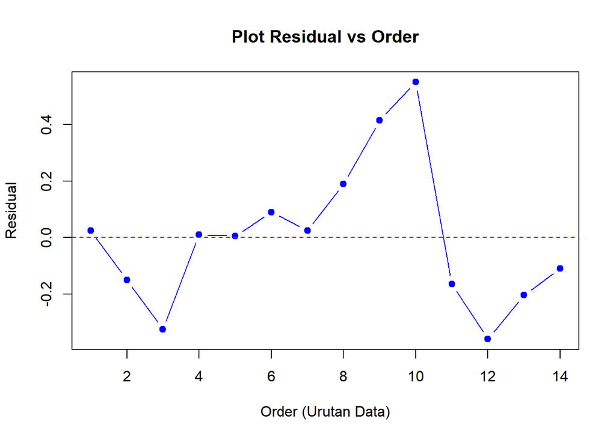

```r
# Ambil residual
res <- residuals(model)

# Plot residual vs urutan data (order)
plot(res, type = "b", pch = 19, col = "blue",
     main = "Plot Residual vs Order",
     xlab = "Order (Urutan Data)",
     ylab = "Residual")

abline(h = 0, lty = 2, col = "red")
```

## 3.3 Plot ACF vs PACF

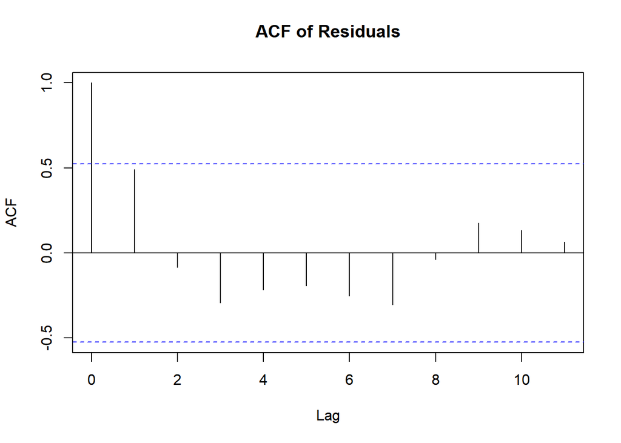

```r
acf(model$residuals, main = "ACF of Residuals")
```

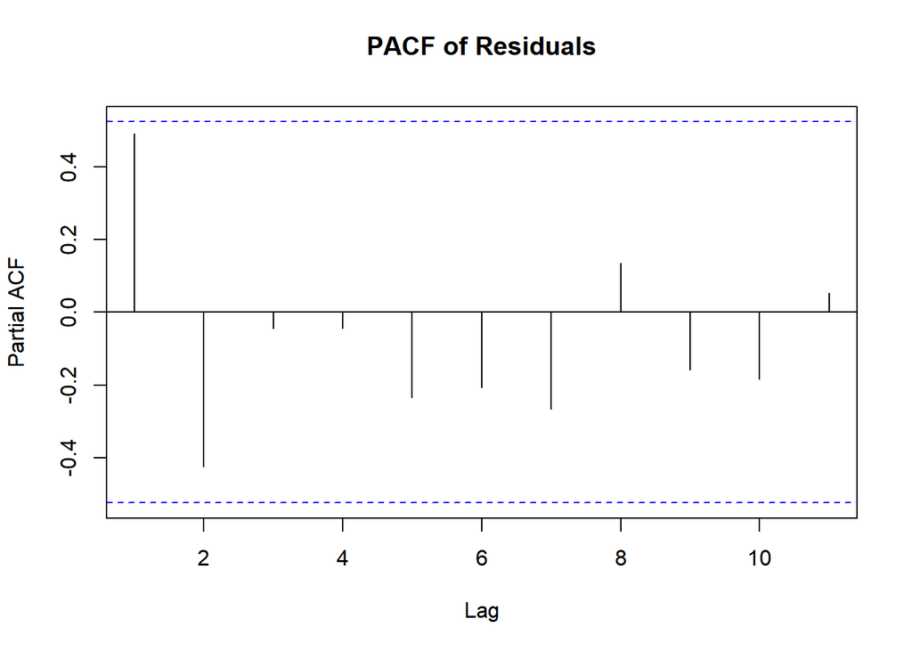

```r
pacf(model$residuals, main = "PACF of Residuals")
```

# 4 Penanganan Autokorelasi

## 4.1 Cochrane-Orcutt

```r
modelCO<-cochrane.orcutt(model)
modelCO
```

```
## Cochrane-orcutt estimation for first order autocorrelation
##
## Call:
## lm(formula = IPM ~ Tahun, data = ipm_riau)
##
##  number of interaction: 5
##  rho 0.499128
##
## Durbin-Watson statistic
## (original):    1.00458 , p-value: 7.206e-03
## (transformed): 1.53822 , p-value: 1.082e-01
##
##  coefficients:
## (Intercept)       Tahun
## -780.892634    0.422649
```

## 4.2 Cochrane-Orcutt Manual

```r
#Rho optimum
rho<- modelCO$rho
rho
```

```
## [1] 0.4991283
```

```r
ipm_riau$IPM[-1]
```

```
##  [1] 68.90 69.15 69.91 70.33 70.84 71.20 71.79 72.44 73.00 72.71 72.94 73.52
## [13] 74.04
```

```r
#Transformasi Manual
gdp.trans <- ipm_riau$IPM[-1] - rho * ipm_riau$IPM[-length(ipm_riau$IPM)]
tahun.trans <- ipm_riau$Tahun[-1] - rho * ipm_riau$Tahun[-length(ipm_riau$Tahun)]

# model regresi setelah transformasi
modelCOmanual <- lm(gdp.trans ~ tahun.trans)
summary(modelCOmanual)
```

```
##
## Call:
## lm(formula = gdp.trans ~ tahun.trans)
##
## Residuals:
##      Min       1Q   Median       3Q      Max
## -0.42965 -0.16321  0.00281  0.17384  0.35156
##
## Coefficients:
##               Estimate Std. Error t value Pr(>|t|)
## (Intercept) -391.12705   36.31819  -10.77 3.51e-07 ***
## tahun.trans    0.42265    0.03593   11.76 1.43e-07 ***
## ---
## Signif. codes:  0 '***' 0.001 '**' 0.01 '*' 0.05 '.' 0.1 ' ' 1
##
## Residual standard error: 0.2428 on 11 degrees of freedom
## Multiple R-squared:  0.9264, Adjusted R-squared:  0.9197
## F-statistic: 138.4 on 1 and 11 DF,  p-value: 1.428e-07
```

```r
#Mencari Penduga Koefisien Regresi setelah Transformasi ke Persamaan Awal
b0bintang <- modelCOmanual$coefficients[-2]
b0 <- b0bintang/(1-rho)
b1 <- modelCOmanual$coefficients[-1]
b0
```

```
## (Intercept)
##   -780.8926
```

```r
b1
```

```
## tahun.trans
##   0.4226486
```

Hasil keluaran model setelah dilakukan penanganan dengan cara manual metode Cochrane-Orcutt adalah
$$y_i=-780.892+0.422x_t$$

## 4.3 Hildreth-Lu

```r
hildreth.lu.func<- function(r, model){
  x <- model.matrix(model)[,-1]
  y <- model.response(model.frame(model))
  n <- length(y)
  t <- 2:n
  y <- y[t]-r*y[t-1]
  x <- x[t]-r*x[t-1]

  return(lm(y~x))
}

#Pencariab rho yang meminimumkan SSE
r <- c(seq(0.1,0.9, by= 0.1))
tab <- data.frame("rho" = r, "SSE" = sapply(r, function(i){deviance(hildreth.lu.func(i, model))}))
round(tab, 4)
```

```
##   rho    SSE
## 1 0.1 0.7828
## 2 0.2 0.7239
## 3 0.3 0.6819
## 4 0.4 0.6567
## 5 0.5 0.6484
## 6 0.6 0.6570
## 7 0.7 0.6825
## 8 0.8 0.7248
## 9 0.9 0.7840
```

Pada hasil di atas terlihat $ρ$ minimum ketika 0.5. Namun, hasil tersebut masih kurang teliti sehingga akan dicari kembali $ρ$ yang lebih optimum dengan ketelitian yang lebih, yaitu dengan jarak antar $ρ$ adalah 0.001 dan dilakukan pada selang 0.6 sampai dengan 0.3.

```r
rOpt <- seq(0.3,0.6, by= 0.001)
tabOpt <- data.frame("rho" = rOpt, "SSE" = sapply(rOpt, function(i){deviance(hildreth.lu.func(i, model))}))
head(tabOpt[order(tabOpt$SSE),])
```

```
##       rho       SSE
## 200 0.499 0.6484406
## 201 0.500 0.6484412
## 199 0.498 0.6484416
## 202 0.501 0.6484435
## 198 0.497 0.6484444
## 203 0.502 0.6484475
```

Perhitungan yang dilakukan aplikasi `R` menunjukkan bahwa nilai $ρ$ optimum, yaitu saat SSE terkecil terdapat pada nilai $ρ=0.499$. Hal tersebut juga ditunjukkan pada plot.

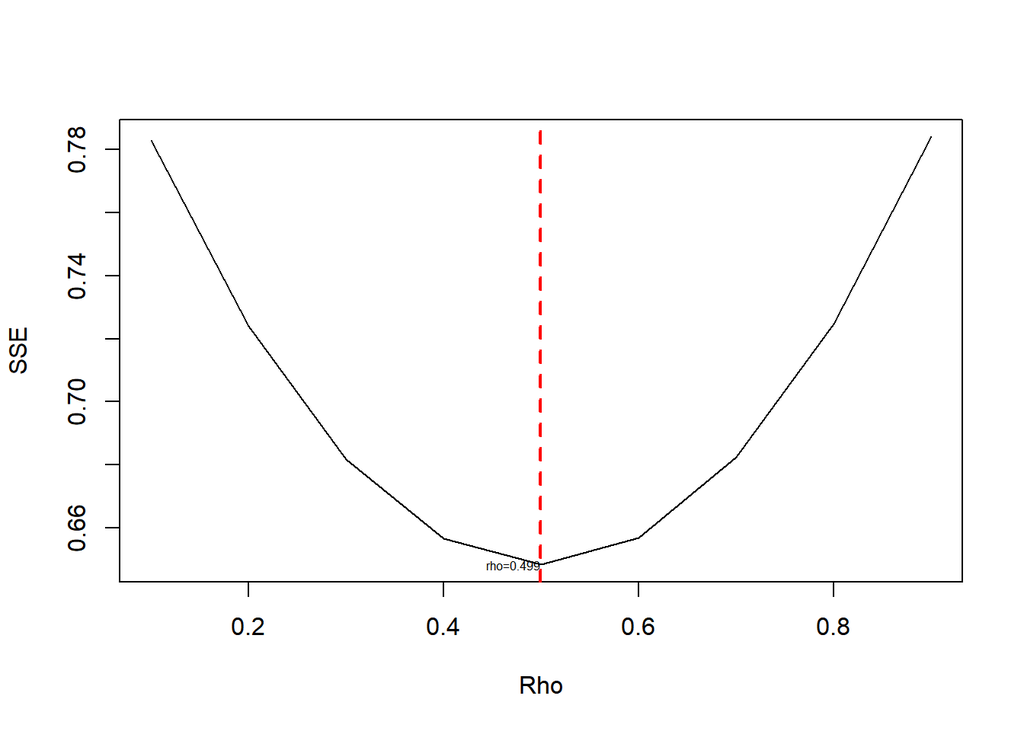

```r
#Grafik SSE optimum
par(mfrow = c(1,1))
plot(tab$SSE ~ tab$rho , type = "l", xlab = "Rho", ylab = "SSE")
abline(v = tabOpt[tabOpt$SSE==min(tabOpt$SSE),"rho"], lty = 2, col="red",lwd=2)
text(x=0.499, y=0.6484406, labels = "rho=0.499", cex = 0.499, adj=1)
```

```r
#Model terbaik
modelHL <- hildreth.lu.func(0.499, model)
summary(modelHL)
```

```
##
## Call:
## lm(formula = y ~ x)
##
## Residuals:
##      Min       1Q   Median       3Q      Max
## -0.42958 -0.16320  0.00282  0.17380  0.35161
##
## Coefficients:
##               Estimate Std. Error t value Pr(>|t|)
## (Intercept) -391.22888   36.31818  -10.77 3.50e-07 ***
## x              0.42265    0.03592   11.77 1.42e-07 ***
## ---
## Signif. codes:  0 '***' 0.001 '**' 0.01 '*' 0.05 '.' 0.1 ' ' 1
##
## Residual standard error: 0.2428 on 11 degrees of freedom
## Multiple R-squared:  0.9264, Adjusted R-squared:  0.9197
## F-statistic: 138.4 on 1 and 11 DF,  p-value: 1.424e-07
```

```r
#Transformasi Balik
cat("y = ", coef(modelHL)[1]/(1-0.499), "+", coef(modelHL)[2],"x", sep = "")
```

```
## y = -780.896+0.4226503x
```

Setelah dilakukan tranformasi balik, didapatkan model dengan metode Hildreth-Lu sebagai berikut.
$$y_i=-780.896+0.422x_t$$

```r
#Deteksi autokorelasi
dwtest(modelHL)
```

```
##
##  Durbin-Watson test
##
## data:  modelHL
## DW = 1.5381, p-value = 0.1081
## alternative hypothesis: true autocorrelation is greater than 0
```

```r
sseModelawal <- anova(model)$`Sum Sq`[-1]
sseModelCO <- anova(modelCOmanual)$`Sum Sq`[-1]
sseModelHL <- anova(modelHL)$`Sum Sq`[-1]
mseModelawal <- sseModelawal/length(ipm_riau$IPM)
mseModelCO <- sseModelCO/length(ipm_riau$IPM)
mseModelHL <- sseModelHL/length(ipm_riau$IPM)
akurasi <- matrix(c(sseModelawal,sseModelCO,sseModelHL,
                    mseModelawal,mseModelCO,mseModelHL),nrow=2,ncol=3,byrow = T)
colnames(akurasi) <- c("Model Awal", "Model Cochrane-Orcutt", "Model Hildreth-Lu")
row.names(akurasi) <- c("SSE","MSE")
akurasi
```

```
##     Model Awal Model Cochrane-Orcutt Model Hildreth-Lu
## SSE  0.8593719            0.64844057        0.64844058
## MSE  0.0613837            0.04631718        0.04631718
```

Data **IPM di Riau tahun 2010–2023** menunjukkan adanya autokorelasi pada model awal.

Berdasarkan hasil analisis, dapat diketahui bahwa penanganan autokorelasi dengan metode **Cochrane-Orcutt** menghasilkan nilai **SSE = 0.6484** dan **MSE = 0.0463**, yang lebih kecil dibandingkan dengan model awal (**SSE = 0.8594**, **MSE = 0.0614**).

Hasil metode **Hildreth-Lu** juga memberikan nilai SSE dan MSE yang hampir identik dengan Cochrane-Orcutt, yaitu **SSE = 0.6484** dan **MSE = 0.0463**.

Dengan demikian, kedua metode mampu memperbaiki masalah autokorelasi pada data IPM Riau, dan hasilnya jauh lebih baik dibandingkan model awal. Karena nilai SSE dan MSE yang dihasilkan Cochrane-Orcutt serta Hildreth-Lu sama-sama lebih kecil, maka keduanya dapat dianggap sama baiknya dalam menangani autokorelasi pada data ini.